RESTREPO ZAPATA Homero 3670794 Rapport partie ODE scalaire

# Graphiques python pour l'EDO Scalaire du premier ordre

## Comparaison des solutions numériques avec la théorie

### Integration par la méthode d'euler

- Pour un pas de 0.1

```
 > fichier data/euler_0.1.txt : 3 lignes d'entete
 < Le graphique data/euler_0.1.pdf a ete cree.
   	Vous pouvez le visualiser avec :  okular data/euler_0.1.pdf
```

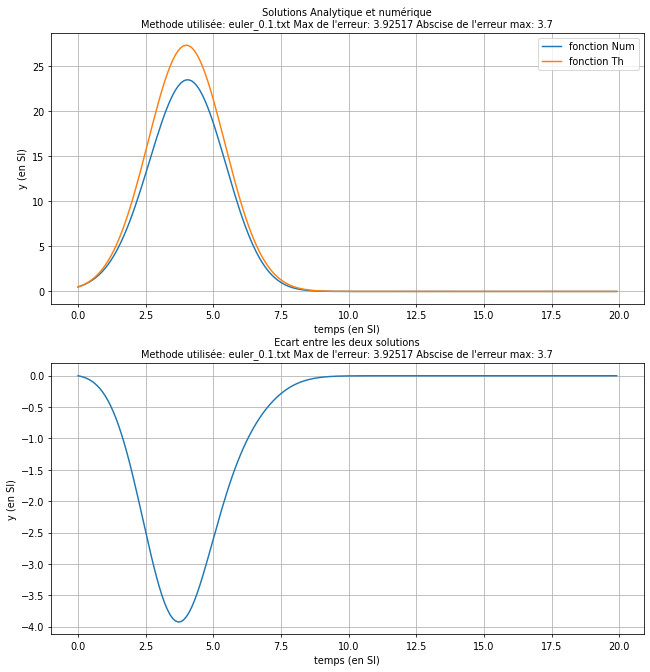

- Pour un pas de 0.2

```
 > fichier data/euler_0.2.txt : 3 lignes d'entete
 < Le graphique data/euler_0.2.pdf a ete cree.
   	Vous pouvez le visualiser avec :  okular data/euler_0.2.pdf
```

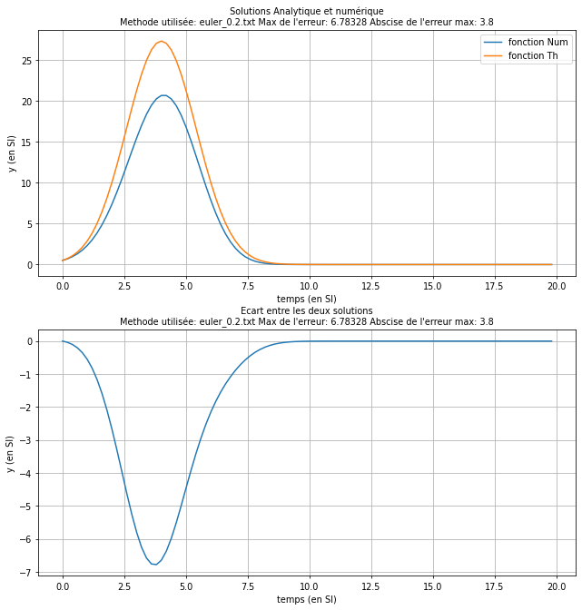

On observe un rapport de $$ \frac{ERROR_{0.2}}{ERROR_{0.1}} = 1.728149 $$

Ce qui nous permet de deduire que la diminution du pas par un facteur 2 permet de diminuer l'arreur d'un facteur 2 environ. Ce qu'est en accord avec le cours car l'erreur globale de cette methode a un comportement de la forme: $$ \propto h $$, où h est le pas considéré.

### Integration par la méthode des points milieux

- Pour un pas de 0.1:

```
 > fichier data/pm_0.1.txt : 3 lignes d'entete
 < Le graphique data/pm_0.1.pdf a ete cree.
   	Vous pouvez le visualiser avec :  okular data/pm_0.1.pdf
```

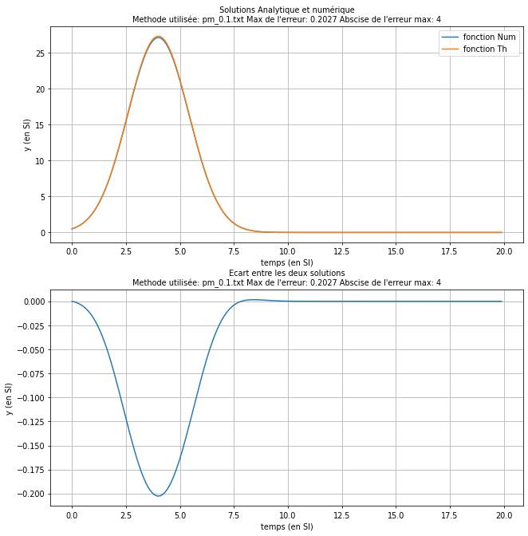

- Pour un pas de 0.2:

```
 > fichier data/pm_0.2.txt : 3 lignes d'entete
 < Le graphique data/pm_0.2.pdf a ete cree.
   	Vous pouvez le visualiser avec :  okular data/pm_0.2.pdf
```

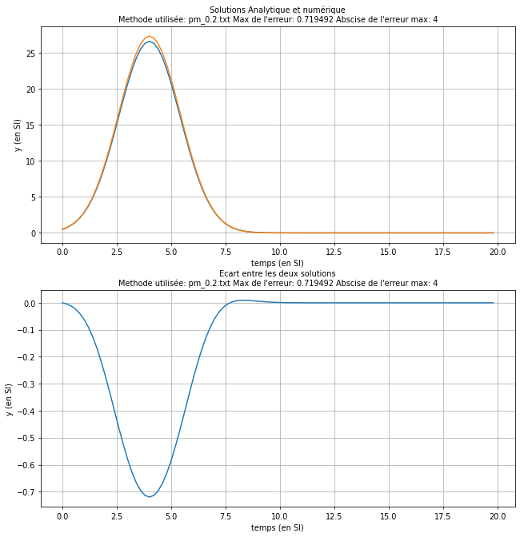

On observe un rapport de $$ \frac{ERROR_{0.2}}{ERROR_{0.1}} = 3.549541 $$

Ce qui nous permet de deduire que la diminution du pas par un facteur 2 permet de diminuer l'arreur d'un facteur 4 environ. Ce qu'est en accord avec le cours car l'erreur globale de cette methode a un comportement de la forme: $$ \propto h^2 $$, où h est le pas considéré.

### Integration par la methode RK4

- Pour un pas de 0.1

```
 > fichier data/rk_0.1.txt : 3 lignes d'entete
 < Le graphique data/rk_0.1.pdf a ete cree.
   	Vous pouvez le visualiser avec :  okular data/rk_0.1.pdf
```

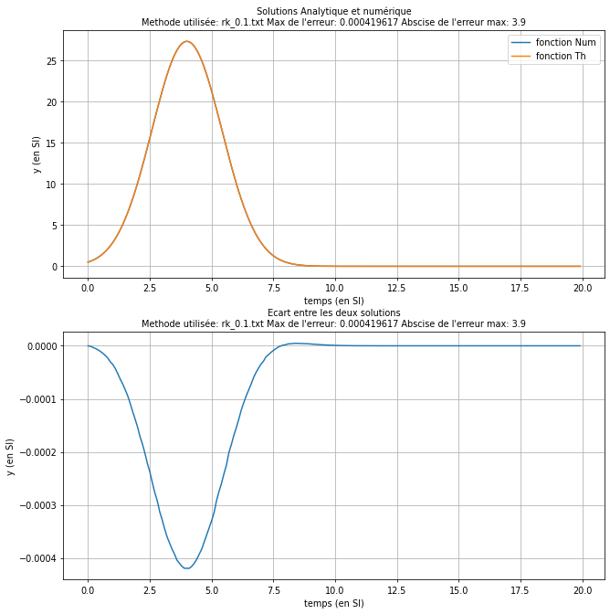

- Pour un pas de 0.2

```
 > fichier data/rk_0.2.txt : 3 lignes d'entete
 < Le graphique data/rk_0.2.pdf a ete cree.
   	Vous pouvez le visualiser avec :  okular data/rk_0.2.pdf
```

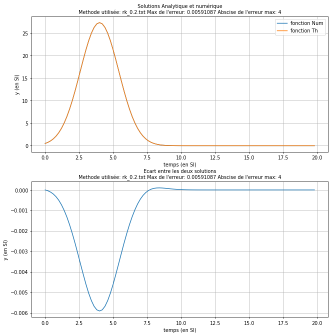

On observe un rapport de $$ \frac{ERROR_{0.2}}{ERROR_{0.1}} = 14.086345 $$

Ce qui nous permet de deduire que la diminution du pas par un facteur 2 permet de diminuer l'arreur d'un facteur $14 (\approx 16 \pm 2)$ environ. Ce qui commence à s'éloigner un peu de la théorie vue en cours car l'erreur globale de cette methode a un comportement de la forme: $$ \propto h^4 $$, où h est le pas considéré.

## Observations Generales

- On observe que lorsqu'on diminue le pas d'integration on diminue l'erreur maximale absolue entre la solution numérique et la solution analytique.
- On observe que l'erreur est de troncature car les écarts entre la solution numérique et analytique sont continus.
- On voit que l'integrtion à partir de methodes d'integration d'ordre superieur permet de diminuer l'erreur maximale considérablement. Par exemple la methode d'Euler a une erreur qui semble linéaire avce le pas. Alors que la methode des points milieux nous permet d'avoir une erreur qui varie comme le carré du pas et avec celle de RK4 on a une erreur en puissance 4 du pas. Ceci nous permet de penser qu'en diminuant le pas on aura des résultats de plus en plus précis.
- Une étude plus détaillé des erreurs en fonction des pas d'integration nous permettrait d'optimiser cette grandeur dans l'objectif de minimiser l'erreur globale.

## Optimisation du pas d'integration

L'objectif de cette partie est d'effectuer une étude de même nature pour des pas plus petits

### Pour un pas de 0.01

- Par la méthode d'Euler

```
 > fichier data/euler_0.01.txt : 3 lignes d'entete
 < Le graphique data/euler_0.01.pdf a ete cree.
   	Vous pouvez le visualiser avec :  okular data/euler_0.01.pdf
```

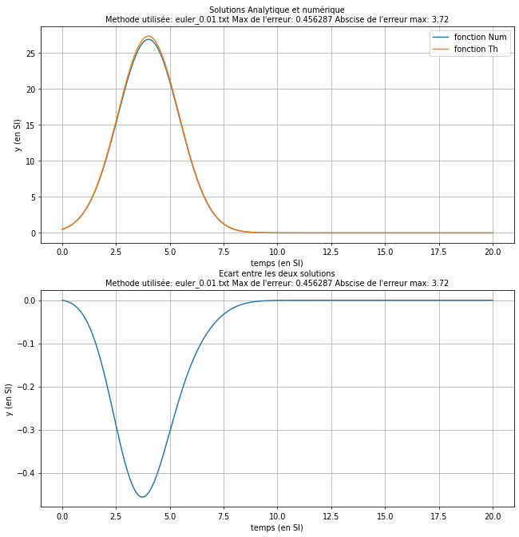

On observe un rapport de $$ \frac{ERROR_{0.1}}{ERROR_{0.01}} = 8.602415 $$

- Par la méthode des points milieux

```
 > fichier data/pm_0.01.txt : 3 lignes d'entete
 < Le graphique data/pm_0.01.pdf a ete cree.
   	Vous pouvez le visualiser avec :  okular data/pm_0.01.pdf
```

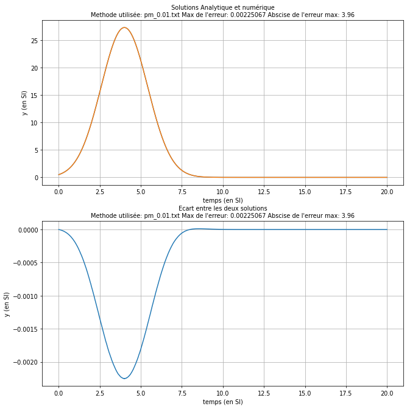

On observe un rapport de $$ \frac{ERROR_{0.1}}{ERROR_{0.01}} = 90.062070 $$

#### Ramarque:

On observe que ces deux méthodes continuent à avoir une erreur globale dominére par celle de troncature ( $\propto h^2$ pour points milieux et $\propto h$ pour euler)

- Par la méthode de RK4

```
 > fichier data/rk_0.01.txt : 3 lignes d'entete
 < Le graphique data/rk_0.01.pdf a ete cree.
   	Vous pouvez le visualiser avec :  okular data/rk_0.01.pdf
```

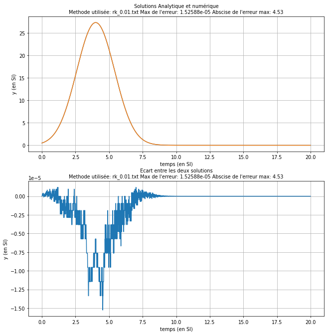

On observe un rapport de $$ \frac{ERROR_{0.1}}{ERROR_{0.01}} = 27.500000 $$

### Pour un pas de 0.001

- Par la méthode d'Euler

```
 > fichier data/euler_0.001.txt : 3 lignes d'entete
 < Le graphique data/euler_0.001.pdf a ete cree.
   	Vous pouvez le visualiser avec :  okular data/euler_0.001.pdf
```

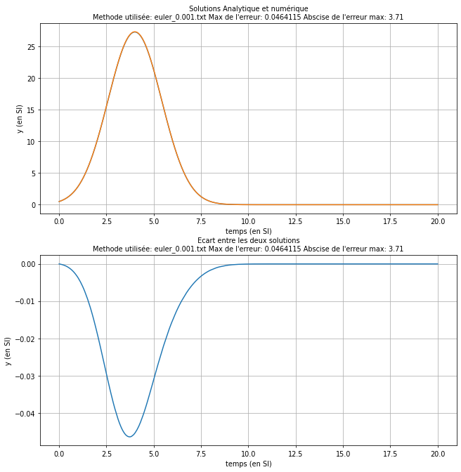

On observe un rapport de $$ \frac{ERROR_{0.01}}{ERROR_{0.001}} = 9.831335 $$

- Par la méthode des points milieux

```
 > fichier data/pm_0.001.txt : 3 lignes d'entete
 < Le graphique data/pm_0.001.pdf a ete cree.
   	Vous pouvez le visualiser avec :  okular data/pm_0.001.pdf
```

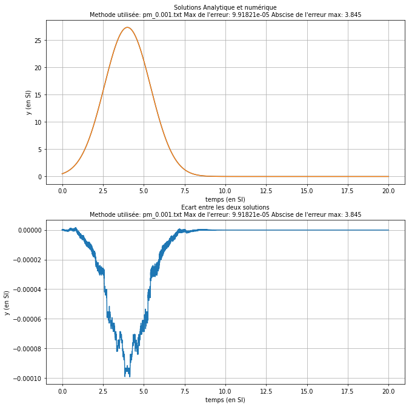

On observe un rapport de $$ \frac{ERROR_{0.01}}{ERROR_{0.001}} = 22.692300 $$

- Par la méthode de RK4

```
 > fichier data/rk_0.001.txt : 3 lignes d'entete
 < Le graphique data/rk_0.001.pdf a ete cree.
   	Vous pouvez le visualiser avec :  okular data/rk_0.001.pdf
```

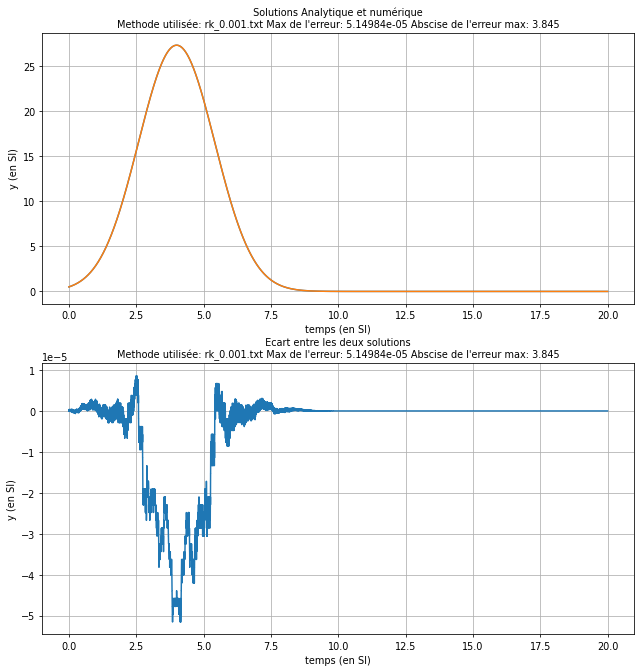

On observe un rapport de $$ \frac{ERROR_{0.01}}{ERROR_{0.001}} = 0.296297 $$

## Conclusions generales sur l'optimisation du pas

On observe que:

- L'erreur aléatoire commence à être non négligeable pour les méthodes de rk4 et points milieux
- Pour la méthode d'euler on continue à avoir une erreur globale dominée par l'erreur de troncature. On en deduit qu'il faudrait continuer à diminuer le pas pour minimiser l'erreur globale. On déduit que les calculs seront plus lourds.
- rk4 minimise l'erreur pour un pas de l'ordre de 0.01. On considère ce pas car les erreurs globales étant domminées par les erreurs de nature aléatoire on commence à observer que même si on diminue le pas on a une variation de l'arreur qui se stabilise. Donc pour des motifs de rendement on choisit le pas de 0.01 comme pas optimale permetant d'avoir des résultats plus fins sans demander beaucoup de calculs.
- Pour la méthode des points milieux on observe que l'erreur globale commence à être dominée par des erreurs aléatoires. On deduit que la methode donne le meilleur rendement pour un pas 0.001 car le rapport entre les erreurs reste encore non négligeable devant 1. Donc on deduit que cette méthode continue à donner des résultats plus fins pour un pas plus petit. Cepandant elle demande plus de temps de calcul en contre partie.